# boston_housing_analysis_ajh

```python
import pandas as pd
import numpy as np
import seaborn as sns
from scipy import stats
from sklearn.model_selection import train_test_split, cross_val_score
from sklearn.linear_model import LinearRegression
from sklearn.metrics import mean_squared_error, r2_score
from sklearn import metrics
import matplotlib.pyplot as plt
%matplotlib inline

import warnings
warnings.filterwarnings('ignore')
```

```python
housing = pd.read_csv('housing.data', delim_whitespace=True, header=None)
```

```python
housing.head()
```

|  | 0 | 1 | 2 | 3 | 4 | 5 | 6 | 7 | 8 | 9 | 10 | 11 | 12 | 13 |
| --- | --- | --- | --- | --- | --- | --- | --- | --- | --- | --- | --- | --- | --- | --- |
| 0 | 0.00632 | 18.0 | 2.31 | 0 | 0.538 | 6.575 | 65.2 | 4.0900 | 1 | 296.0 | 15.3 | 396.90 | 4.98 | 24.0 |
| 1 | 0.02731 | 0.0 | 7.07 | 0 | 0.469 | 6.421 | 78.9 | 4.9671 | 2 | 242.0 | 17.8 | 396.90 | 9.14 | 21.6 |
| 2 | 0.02729 | 0.0 | 7.07 | 0 | 0.469 | 7.185 | 61.1 | 4.9671 | 2 | 242.0 | 17.8 | 392.83 | 4.03 | 34.7 |
| 3 | 0.03237 | 0.0 | 2.18 | 0 | 0.458 | 6.998 | 45.8 | 6.0622 | 3 | 222.0 | 18.7 | 394.63 | 2.94 | 33.4 |
| 4 | 0.06905 | 0.0 | 2.18 | 0 | 0.458 | 7.147 | 54.2 | 6.0622 | 3 | 222.0 | 18.7 | 396.90 | 5.33 | 36.2 |

```python
column_name = ['CRIM', 'ZN', 'INDUS', 'CHAS', 'NOX', 'RM', 'AGE', 'DIS', 'RAD', 'TAX', 'PTRATIO', 'B', 'LSTAT', 'MEDV']

housing.columns = column_name
housing.head()
```

|  | CRIM | ZN | INDUS | CHAS | NOX | RM | AGE | DIS | RAD | TAX | PTRATIO | B | LSTAT | MEDV |
| --- | --- | --- | --- | --- | --- | --- | --- | --- | --- | --- | --- | --- | --- | --- |
| 0 | 0.00632 | 18.0 | 2.31 | 0 | 0.538 | 6.575 | 65.2 | 4.0900 | 1 | 296.0 | 15.3 | 396.90 | 4.98 | 24.0 |
| 1 | 0.02731 | 0.0 | 7.07 | 0 | 0.469 | 6.421 | 78.9 | 4.9671 | 2 | 242.0 | 17.8 | 396.90 | 9.14 | 21.6 |
| 2 | 0.02729 | 0.0 | 7.07 | 0 | 0.469 | 7.185 | 61.1 | 4.9671 | 2 | 242.0 | 17.8 | 392.83 | 4.03 | 34.7 |
| 3 | 0.03237 | 0.0 | 2.18 | 0 | 0.458 | 6.998 | 45.8 | 6.0622 | 3 | 222.0 | 18.7 | 394.63 | 2.94 | 33.4 |
| 4 | 0.06905 | 0.0 | 2.18 | 0 | 0.458 | 7.147 | 54.2 | 6.0622 | 3 | 222.0 | 18.7 | 396.90 | 5.33 | 36.2 |

```python
housing.shape
```

```
(506, 14)
```

```python
housing.info()
```

```
<class 'pandas.core.frame.DataFrame'>
RangeIndex: 506 entries, 0 to 505
Data columns (total 14 columns):
 #   Column   Non-Null Count  Dtype
---  ------   --------------  -----
 0   CRIM     506 non-null    float64
 1   ZN       506 non-null    float64
 2   INDUS    506 non-null    float64
 3   CHAS     506 non-null    int64
 4   NOX      506 non-null    float64
 5   RM       506 non-null    float64
 6   AGE      506 non-null    float64
 7   DIS      506 non-null    float64
 8   RAD      506 non-null    int64
 9   TAX      506 non-null    float64
 10  PTRATIO  506 non-null    float64
 11  B        506 non-null    float64
 12  LSTAT    506 non-null    float64
 13  MEDV     506 non-null    float64
dtypes: float64(12), int64(2)
memory usage: 55.5 KB
```

```python
housing.describe()
```

|  | CRIM | ZN | INDUS | CHAS | NOX | RM | AGE | DIS | RAD | TAX | PTRATIO | B | LSTAT | MEDV |
| --- | --- | --- | --- | --- | --- | --- | --- | --- | --- | --- | --- | --- | --- | --- |
| count | 506.000000 | 506.000000 | 506.000000 | 506.000000 | 506.000000 | 506.000000 | 506.000000 | 506.000000 | 506.000000 | 506.000000 | 506.000000 | 506.000000 | 506.000000 | 506.000000 |
| mean | 3.613524 | 11.363636 | 11.136779 | 0.069170 | 0.554695 | 6.284634 | 68.574901 | 3.795043 | 9.549407 | 408.237154 | 18.455534 | 356.674032 | 12.653063 | 22.532806 |
| std | 8.601545 | 23.322453 | 6.860353 | 0.253994 | 0.115878 | 0.702617 | 28.148861 | 2.105710 | 8.707259 | 168.537116 | 2.164946 | 91.294864 | 7.141062 | 9.197104 |
| min | 0.006320 | 0.000000 | 0.460000 | 0.000000 | 0.385000 | 3.561000 | 2.900000 | 1.129600 | 1.000000 | 187.000000 | 12.600000 | 0.320000 | 1.730000 | 5.000000 |
| 25% | 0.082045 | 0.000000 | 5.190000 | 0.000000 | 0.449000 | 5.885500 | 45.025000 | 2.100175 | 4.000000 | 279.000000 | 17.400000 | 375.377500 | 6.950000 | 17.025000 |
| 50% | 0.256510 | 0.000000 | 9.690000 | 0.000000 | 0.538000 | 6.208500 | 77.500000 | 3.207450 | 5.000000 | 330.000000 | 19.050000 | 391.440000 | 11.360000 | 21.200000 |
| 75% | 3.677082 | 12.500000 | 18.100000 | 0.000000 | 0.624000 | 6.623500 | 94.075000 | 5.188425 | 24.000000 | 666.000000 | 20.200000 | 396.225000 | 16.955000 | 25.000000 |
| max | 88.976200 | 100.000000 | 27.740000 | 1.000000 | 0.871000 | 8.780000 | 100.000000 | 12.126500 | 24.000000 | 711.000000 | 22.000000 | 396.900000 | 37.970000 | 50.000000 |

```python
housing.to_csv('housing.csv', header=True, index=False)
```

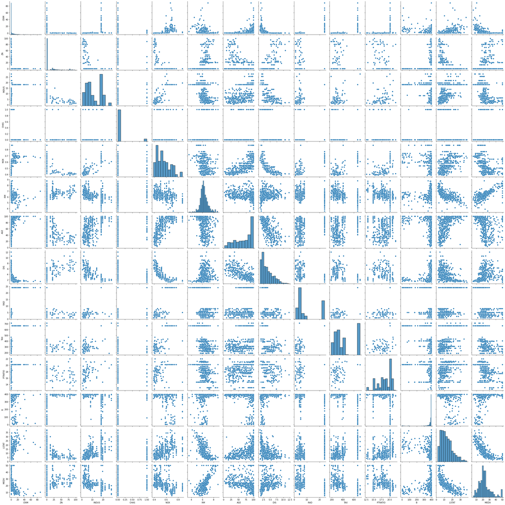

```python
sns.pairplot(housing)
```

- 선형 모델 적용 가능 여부 검토 : 데이터 변환 필요성 등

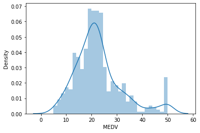

```python
sns.distplot(housing['MEDV'], bins=30)
plt.show()
```

목적변수인 MEDV(주택가격)은 정규분포를 이루고 있어 선형회귀 모델을 적용하기에 적합하다. ($50000 가격에 이상치가 조금 있으나 제거할 정도는 아님)

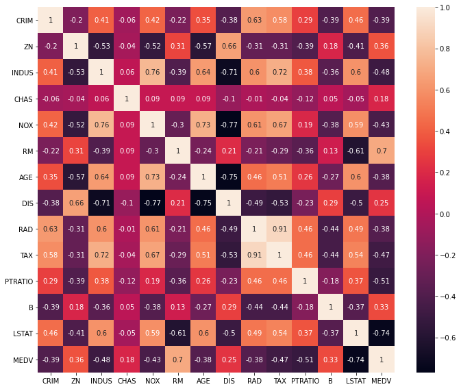

```python
plt.figure(figsize=(10, 8))
sns.heatmap(housing.corr().round(2), annot=True)
plt.tight_layout()
plt.show()
```

### 1. 다중선형회귀

- 절대값 0.5 이상인 변수 3개로 만든 가장 간단한 모델

```python
y_target = housing['MEDV']
X_data = housing[['RM', 'LSTAT', 'PTRATIO']]

X_train, X_test, y_train, y_test = train_test_split(X_data, y_target, test_size = 0.2, random_state=42)
```

```python
model = LinearRegression()
model.fit(X_train, y_train)

y_train_preds = model.predict(X_train)
y_test_preds = model.predict(X_test)
```

```python
# evaluating the model on training dataset
mse_train = mean_squared_error(y_train, y_train_preds)
rmse_train = np.sqrt(mse_train)

# evaluating the model on test dataset
mse_test = mean_squared_error(y_test, y_test_preds)
rmse_test = np.sqrt(mse_test)

print("The model performance for the training set")
print("-------------------------------------------")
print('MSE : {0:.3f}, RMSE : {1:.3F}'.format(mse_train, rmse_train))
print('Variance score : {0:.3f}'.format(r2_score(y_train, y_train_preds)))
print('\n')
print("The model performance for the test set")
print("-------------------------------------------")
print('MSE : {0:.3f}, RMSE : {1:.3F}'.format(mse_test, rmse_test))
print('Variance score : {0:.3f}'.format(r2_score(y_test, y_test_preds)))
```

```
The model performance for the training set
-------------------------------------------
MSE : 27.239, RMSE : 5.219
Variance score : 0.686


The model performance for the test set
-------------------------------------------
MSE : 27.115, RMSE : 5.207
Variance score : 0.630
```

모형의 정밀도(RMSE)는 5.207, 분산점수(Variance score)는 0.630으로 이 세개의 변수는 주택가격의 63.0%를 설명한다 (이하 설명력 63.0%)

- 모든 변수를 다 사용해 만든 모델

```python
y_target = housing['MEDV']
X_data = housing.drop(['MEDV'], axis=1, inplace=False)

X_train, X_test, y_train, y_test = train_test_split(X_data, y_target, test_size = 0.2, random_state=42)
```

```python
model = LinearRegression()
model.fit(X_train, y_train)

y_train_preds = model.predict(X_train)
y_test_preds = model.predict(X_test)
```

```python
# evaluating the model on training dataset
mse_train = mean_squared_error(y_train, y_train_preds)
rmse_train = np.sqrt(mse_train)

# evaluating the model on test dataset
mse_test = mean_squared_error(y_test, y_test_preds)
rmse_test = np.sqrt(mse_test)

print("The model performance for the training set")
print("-------------------------------------------")
print('MSE : {0:.3f}, RMSE : {1:.3F}'.format(mse_train, rmse_train))
print('Variance score : {0:.3f}'.format(r2_score(y_train, y_train_preds)))
print('\n')
print("The model performance for the test set")
print("-------------------------------------------")
print('MSE : {0:.3f}, RMSE : {1:.3F}'.format(mse_test, rmse_test))
print('Variance score : {0:.3f}'.format(r2_score(y_test, y_test_preds)))
```

```
The model performance for the training set
-------------------------------------------
MSE : 21.641, RMSE : 4.652
Variance score : 0.751


The model performance for the test set
-------------------------------------------
MSE : 24.291, RMSE : 4.929
Variance score : 0.669
```

모든 변수를 사용함으로써 모형의 정밀도(RMSE)는 4.929, 설명력은 66.9%로 개선되었다.

#### 변수 선택 관련 이슈 - p-value 기반한 선택

회귀분석에서 변수 선택의 기준은 전통적으로 p-value이다. p-value에 기반해 모델에 변수를 추가하거나 제거하며, 방향에 따라 forward, backward, both 방식이 있다. 하지만, 'p-value가 실제 상황을 반영하는가?' 라는 질문에는 '그렇지 않다'고 조심스럽게 말하고 싶다. domain knowledge나 경험칙/상식적인 수준에서 '실질적 유의미'성이 있다고 판단한 변수가 '통계적 유의미'성은 없다고 판명되는 경우, 이 변수는 모델에서 제외되어야 하는가?

변수 갯수가 적은 보스턴 데이터가 아닌 수백개의 변수를 다루는 데이터에서 p-value 방식으로 변수를 채택하는 경우에는, 분석을 시행할 때마다 남는 변수가 달라지는 문제가 실제로 발생한다. 무의미한 변수 하나를 제거하면, 유의미하던 변수들이 무의미하다고 결정되는 경우도 빈번한데, 이것은 어떻게 해석해야 하는가?

이러한 문제를 고려하여, 본 분석에서는 모델을 설명하기 위해서는 선형회귀 방식을 적용하되 변수 선택에 있어서는 별도의 합리적인 방법을 발견하고자 한다.

#### 참고 : p-value 관련 > "통계적 유의성과 P-값에 대한 성명" (미국통계학회)

- p-value는 데이터가 특정 통계 모형과 얼마나 상반되는지 나타낼 수 있다.
- p-value는 연구 가설이 참일 확률이나, 데이터가 무작위적 우연만으로 생성되었을 확률의 척도가 아니다.
- 과학적 결론과 사업이나 정책적 결정이 p-value가 특정 문턱값을 넘어서는지에 의해서만 내려져서는 안된다.
- 적절한 추론을 위해 “완전한 보고와 투명성”이 필요하다.
- p-value나 통계적 유의성은 “효과의 크기”나 “결과의 중요성”의 척도가 아니다.
- p-value 그 자체만으로는 어떤 모형이나 가설에 관한 증거의 좋은 척도가 아니다.

https://amstat.tandfonline.com/doi/pdf/10.1080/00031305.2016.1154108

http://goo.gl/ZdFvcT

https://www.editage.co.kr/insights/is-my-research-significant-why-you-shouldn%E2%80%99t-rely-on-p-values (번역)

- 통계적 유의성과 과학적, 실질적, 또는 임상적 유의성은 서로 같지 않습니다.

#### 참고 2 : Boston Housing Data 최근 이슈

https://github.com/scikit-learn/scikit-learn/issues/16155

- B 1000(Bk - 0.63)^2 where Bk is the proportion of blacks by town

사이킷런의 load_boston() 함수가 삭제될 예정이다. 이 데이터의 문제는 <도시별 흑인의 비율> 특성인 'B' 때문이다. '흑인 비율이 주택 가격에 미치는 영향' - 이 데이터셋이 수집된 1978년 보스턴이었으면 모를까, 요즘 시대엔 political correctness는 별론으로 하되 현실적으로도 납득하기 어렵다. 이 데이터를 삭제할지 특성만 제거할지 의견이 분분했고, 결론적으로 현재 deprecate 경고가 뜨는 상황이다(향후 삭제 예정). 이러한 이슈를 반영해 본 분석에서는 다중선형회귀 Base 모델로 특성 'B'를 제거하여 사용하였다.

그러나, '빈민가를 떠나려는 흑인의 노력에 대한 백인 공동체의 적대감' 이라는 당시 시대상의 반증(이런 데이터를 수집한 것부터!)등 여러 역사적-데이터적 의미에서 다른 모델에서는 포함시켜 진행하였다.

> "Why not just drop “B” altogether?" https://medium.com/@docintangible/racist-data-destruction-113e3eff54a8
- Base Model :

특성 B만 제외한 다른 변수들로 주택가격 예측

```python
y_target = housing['MEDV']
X_data = housing.drop(['MEDV', 'B'], axis=1, inplace=False)

X_train, X_test, y_train, y_test = train_test_split(X_data, y_target, test_size = 0.2, random_state=42)
```

```python
model = LinearRegression()
model.fit(X_train, y_train)

y_train_preds = model.predict(X_train)
y_test_preds = model.predict(X_test)
```

```python
# evaluating the model on training dataset
mse_train = mean_squared_error(y_train, y_train_preds)
rmse_train = np.sqrt(mse_train)

# evaluating the model on test dataset
mse_test = mean_squared_error(y_test, y_test_preds)
rmse_test = np.sqrt(mse_test)

print("The model performance for the training set")
print("-------------------------------------------")
print('MSE : {0:.3f}, RMSE : {1:.3F}'.format(mse_train, rmse_train))
print('Variance score : {0:.3f}'.format(r2_score(y_train, y_train_preds)))
print('\n')
print("The model performance for the test set")
print("-------------------------------------------")
print('MSE : {0:.3f}, RMSE : {1:.3F}'.format(mse_test, rmse_test))
print('Variance score : {0:.3f}'.format(r2_score(y_test, y_test_preds)))
```

```
The model performance for the training set
-------------------------------------------
MSE : 22.604, RMSE : 4.754
Variance score : 0.740


The model performance for the test set
-------------------------------------------
MSE : 22.778, RMSE : 4.773
Variance score : 0.689
```

Base 모형의 정밀도(RMSE)는 4.773, 설명력은 68.9%로 개선되었다. (모든 변수를 사용했을 때보다 좋다!)

- Base Model 정밀도 교차검증

```python
neg_mse_scores = cross_val_score(model, X_data, y_target, scoring='neg_mean_squared_error', cv=5)
rmse_scores = np.sqrt(-1 * neg_mse_scores)
avg_rmse = np.mean(rmse_scores)

print('5 folds의 개별 RMSE : ', np.round(rmse_scores, 2))
print('5 folds의 평균 RMSE : {0:.3f} '.format(avg_rmse))
```

```
5 folds의 개별 RMSE :  [3.54 5.14 5.86 8.78 5.54]
5 folds의 평균 RMSE : 5.773
```

- Base Model 모형 검증

```python
import statsmodels.formula.api as ols
```

```python
base_test = pd.concat([X_test, y_test], axis=1)
```

```python
res = ols.ols('MEDV ~ CRIM + ZN + INDUS + CHAS + NOX + RM + AGE + DIS + RAD + TAX + PTRATIO + LSTAT', data = base_test).fit()
res.summary()
```

OLS Regression Results

| Dep. Variable: | MEDV | R-squared: | 0.765 |
| --- | --- | --- | --- |
| Model: | OLS | Adj. R-squared: | 0.733 |
| Method: | Least Squares | F-statistic: | 24.13 |
| Date: | Sun, 22 Nov 2020 | Prob (F-statistic): | 5.74e-23 |
| Time: | 12:30:32 | Log-Likelihood: | -289.95 |
| No. Observations: | 102 | AIC: | 605.9 |
| Df Residuals: | 89 | BIC: | 640.0 |
| Df Model: | 12 |  |  |
| Covariance Type: | nonrobust |  |  |

|  | coef | std err | t | P>\|t\| | [0.025 | 0.975] |
| --- | --- | --- | --- | --- | --- | --- |
| Intercept | 66.8666 | 10.953 | 6.105 | 0.000 | 45.104 | 88.629 |
| CRIM | -0.0655 | 0.103 | -0.633 | 0.528 | -0.271 | 0.140 |
| ZN | 0.1159 | 0.027 | 4.335 | 0.000 | 0.063 | 0.169 |
| INDUS | 0.0527 | 0.152 | 0.347 | 0.729 | -0.249 | 0.354 |
| CHAS | 1.4013 | 2.048 | 0.684 | 0.496 | -2.669 | 5.472 |
| NOX | -26.5030 | 9.170 | -2.890 | 0.005 | -44.724 | -8.283 |
| RM | 0.7047 | 0.939 | 0.751 | 0.455 | -1.161 | 2.570 |
| AGE | 0.0289 | 0.033 | 0.873 | 0.385 | -0.037 | 0.095 |
| DIS | -1.5636 | 0.423 | -3.699 | 0.000 | -2.404 | -0.724 |
| RAD | 0.3824 | 0.138 | 2.764 | 0.007 | 0.108 | 0.657 |
| TAX | -0.0139 | 0.009 | -1.610 | 0.111 | -0.031 | 0.003 |
| PTRATIO | -1.1872 | 0.326 | -3.647 | 0.000 | -1.834 | -0.540 |
| LSTAT | -0.6339 | 0.132 | -4.787 | 0.000 | -0.897 | -0.371 |

| Omnibus: | 66.173 | Durbin-Watson: | 1.542 |
| --- | --- | --- | --- |
| Prob(Omnibus): | 0.000 | Jarque-Bera (JB): | 456.992 |
| Skew: | 1.979 | Prob(JB): | 5.83e-100 |
| Kurtosis: | 12.585 | Cond. No. | 1.34e+04 |

Notes:  
[1] Standard Errors assume that the covariance matrix of the errors is correctly specified.  
[2] The condition number is large, 1.34e+04. This might indicate that there are  
strong multicollinearity or other numerical problems.

- Adj. R-squared: 0.733
- F-statistic: 24.13
- Prob (F-statistic): 5.74e-23
- Log-Likelihood: -289.95
- AIC: 605.9
- BIC: 640.0

상호작용이 강한 일부 변수 제거가 필요하지만 Base 모형 정도도 데이터에 잘 맞는다. (변수 유의미성을 p-value 기준으로 본다면 앞서 말했듯이 납득이 어려운 부분이 발견된다.)

- 모형의 설명

```python
print('intercept : ', model.intercept_)
coeff = pd.Series(data=np.round(model.coef_, 3), index=X_data.columns)
coeff.sort_values(ascending=False)
```

```
intercept :  36.970469067029924
```

```
RM          4.240
CHAS        3.049
RAD         0.240
ZN          0.031
INDUS       0.025
AGE        -0.004
TAX        -0.011
CRIM       -0.127
LSTAT      -0.538
PTRATIO    -0.895
DIS        -1.466
NOX       -18.183
dtype: float64
```

일부만 설명하자면 (다른 조건이 같을때),

- 주택당 방의 개수(RM)가 1 증가할때마다 주택 가격은 $4240 증가한다. (집이 크면 당연히 가격이 비싸다)
- 찰스강변에 위치했다면 주택 가격은 $3049 증가한다. (뷰가 좋으면 집값이 비싼것은 1978년에도 그랬다)
- 인구당 범죄율이 1씩 증가할때마다 주택 가격은 $127 감소한다. (우범지역의 집값이 싸다)
- 학생-선생 비율이 1단위 증가할때마다 주택 가격은 $895 감소한다. (교육여건 지표이므로 타당하다)
- 10ppm당 농축 일산화질소 비율이 1단위 증가할때마다 주택 가격은 $18183 감소한다.

  > 일산화질소(NO)는 대기오염의 지표이므로 타당하다! (공장지역 집값이 싼 이유)
- Base Model 시각화

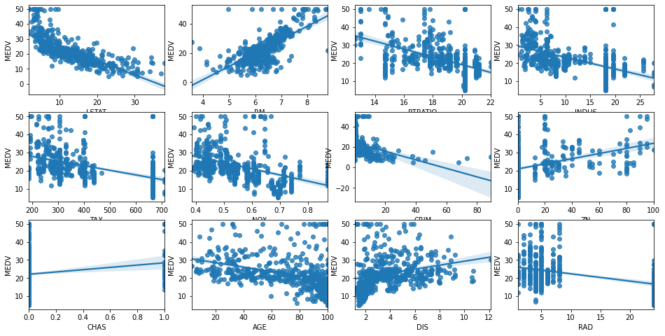

```python
fig, axs = plt.subplots(figsize=(16,8), ncols=4, nrows=3)
features = ['LSTAT','RM', 'PTRATIO', 'INDUS', 'TAX', 'NOX', 'CRIM', 'ZN', 'CHAS', 'AGE', 'DIS', 'RAD']
for i, feature in enumerate(features):
    row = int(i/4)
    col = i%4
    sns.regplot(x=feature, y='MEDV', data=housing, ax=axs[row][col])
```

선형 모델에 잘 적합된 것으로 보인다

- 실제값 / 예측값 비교

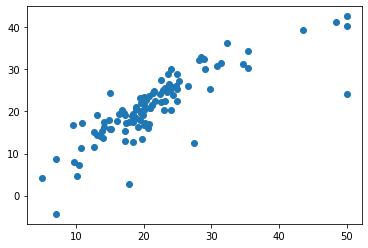

```python
plt.scatter(y_test, y_test_preds)
```

```python
df1 = pd.DataFrame({'Actual': y_test, 'Predicted':y_test_preds})
df2 = df1.head(10)
df2
```

|  | Actual | Predicted |
| --- | --- | --- |
| 173 | 23.6 | 28.958215 |
| 274 | 32.4 | 36.287541 |
| 491 | 13.6 | 14.098836 |
| 72 | 22.8 | 25.033144 |
| 452 | 16.1 | 17.601968 |
| 76 | 20.0 | 23.294368 |
| 316 | 17.8 | 17.414978 |
| 140 | 14.0 | 13.688916 |
| 471 | 19.6 | 22.037299 |
| 500 | 16.8 | 20.300903 |

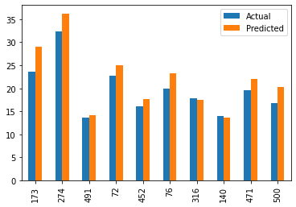

```python
df2.plot(kind = 'bar')
```

Base 모델도 일정수준 이상의 퍼포먼스를 보여주고 있으며 '현상'을 잘 설명해주고 있다.

> 성능과 설명력을 다 잡을 수 있는 더 좋은 모델을 찾아보자.

### 2. 다항회귀

'현실'의 문제는 직선으로만 표현되지 않는다. 회귀가 독립변수의 단항식이 아닌 2차, 3차 등 다항의 방정식으로 표현했을때 더 나은 성능을 보일 수 있다.

##### 1) Polynomial Linear Regression (2차)

```python
from sklearn.preprocessing import PolynomialFeatures
import numpy as np
```

```python
y_target = housing['MEDV']
X_data = housing.drop(['MEDV'], axis=1, inplace=False) ##

X_train, X_test, y_train, y_test = train_test_split(X_data, y_target, test_size = 0.2, random_state=42)
```

```python
poly_features = PolynomialFeatures(degree=2)

X_train_poly = poly_features.fit_transform(X_train)

# fit the transformed features to Linear Regression
poly_model = LinearRegression()
poly_model.fit(X_train_poly, y_train)

# predicting on training data-set
y_train_preds= poly_model.predict(X_train_poly)
y_test_preds = poly_model.predict(poly_features.fit_transform(X_test))
```

```python
# evaluating the model on training dataset
mse_train = mean_squared_error(y_train, y_train_preds)
rmse_train = np.sqrt(mse_train)

# evaluating the model on test dataset
mse_test = mean_squared_error(y_test, y_test_preds)
rmse_test = np.sqrt(mse_test)

print("The model performance for the training set")
print("-------------------------------------------")
print('MSE : {0:.3f}, RMSE : {1:.3F}'.format(mse_train, rmse_train))
print('Variance score : {0:.3f}'.format(r2_score(y_train, y_train_preds)))
print('\n')
print("The model performance for the test set")
print("-------------------------------------------")
print('MSE : {0:.3f}, RMSE : {1:.3F}'.format(mse_test, rmse_test))
print('Variance score : {0:.3f}'.format(r2_score(y_test, y_test_preds)))
```

```
The model performance for the training set
-------------------------------------------
MSE : 5.314, RMSE : 2.305
Variance score : 0.939


The model performance for the test set
-------------------------------------------
MSE : 14.184, RMSE : 3.766
Variance score : 0.807
```

2차 선형 모형의 정밀도(RMSE)는 3.766, 설명력은 80.7%로 개선되었다.

- 2차 선형 모델 정밀도 교차검증

```python
neg_mse_scores = cross_val_score(poly_model, X_data, y_target, scoring='neg_mean_squared_error', cv=5)
rmse_scores = np.sqrt(-1 * neg_mse_scores)
avg_rmse = np.mean(rmse_scores)

print('5 folds의 개별 RMSE : ', np.round(rmse_scores, 2))
print('5 folds의 평균 RMSE : {0:.3f} '.format(avg_rmse))
```

```
5 folds의 개별 RMSE :  [3.53 5.1  5.75 8.99 5.77]
5 folds의 평균 RMSE : 5.829
```

5 folds의 경우 RMSE가 5.773에서 5.829로 증가, 불안정한 것은 과적합이 되었을 가능성을 의미한다.

- 2차 선형 모델 회귀 계수

```python
print('설명변수 갯수 :', len(poly_model.coef_))
print('2차 다항 회귀 계수\n', np.round(poly_model.coef_, 2))
```

```
설명변수 갯수 : 105
2차 다항 회귀 계수
 [-4.92670935e+08 -7.23000000e+00  6.60000000e-01 -4.72000000e+00
  3.67400000e+01  2.85260000e+02  1.78400000e+01  6.60000000e-01
 -4.11000000e+00  2.66000000e+00 -1.00000000e-02  7.65000000e+00
  1.30000000e-01 -2.00000000e-01  0.00000000e+00  7.00000000e-02
  5.80000000e-01  2.59000000e+00 -2.03000000e+00  1.80000000e-01
 -1.00000000e-02 -1.90000000e-01  2.70000000e-01 -4.00000000e-02
  6.90000000e-01 -0.00000000e+00  3.00000000e-02 -0.00000000e+00
 -0.00000000e+00 -6.00000000e-02 -1.38000000e+00 -0.00000000e+00
  0.00000000e+00 -2.00000000e-02 -2.00000000e-02  0.00000000e+00
 -0.00000000e+00  0.00000000e+00 -1.00000000e-02  5.00000000e-02
 -1.00000000e-02 -2.20000000e-01  3.10000000e-01  0.00000000e+00
  1.70000000e-01 -0.00000000e+00 -0.00000000e+00 -3.00000000e-02
  0.00000000e+00 -2.00000000e-02  3.67400000e+01 -3.67200000e+01
 -5.27000000e+00 -3.00000000e-02 -9.20000000e-01  1.30000000e-01
 -1.00000000e-02 -8.40000000e-01  1.00000000e-02 -2.40000000e-01
 -9.84100000e+01 -8.71000000e+00 -5.00000000e-02  1.48000000e+01
 -2.08000000e+00  2.80000000e-01 -1.45000000e+01  0.00000000e+00
  1.01000000e+00  1.13000000e+00 -7.00000000e-02 -3.30000000e-01
 -1.80000000e-01 -1.00000000e-02 -5.60000000e-01 -1.00000000e-02
 -4.00000000e-02 -0.00000000e+00  0.00000000e+00  1.00000000e-02
 -0.00000000e+00  0.00000000e+00 -0.00000000e+00 -1.00000000e-02
  5.00000000e-01  7.00000000e-02 -1.00000000e-02 -2.60000000e-01
 -0.00000000e+00  4.00000000e-02 -8.00000000e-02  0.00000000e+00
 -1.70000000e-01  0.00000000e+00 -3.00000000e-02 -0.00000000e+00
  1.00000000e-02 -0.00000000e+00 -0.00000000e+00 -3.00000000e-02
  1.00000000e-02  3.00000000e-02 -0.00000000e+00 -0.00000000e+00
  2.00000000e-02]
```

입력변수를 2차 다항값으로 변환하며 해석해야 할 변수 13개가 105개로 증가했다.

다항 모델의 문제점은 이것이다. 분석은 했지만 해석을 하는 것이 극도로 어려워진다. 변수 갯수 문제도 있지만, '다항'이라는 문제도 그렇다.

> '범죄율 * 일산화질소'항의 회귀계수가 주택가격에 미치는 영향력을 어떻게 설명할 것인가?

##### 3) Polynomial Linear Regression (3차)

```python
poly_features = PolynomialFeatures(degree=3)

X_train_poly = poly_features.fit_transform(X_train)

# fit the transformed features to Linear Regression
poly_model = LinearRegression()
poly_model.fit(X_train_poly, y_train)

# predicting on training data-set
y_train_preds= poly_model.predict(X_train_poly)
y_test_preds = poly_model.predict(poly_features.fit_transform(X_test))
```

```python
# evaluating the model on training dataset
mse_train = mean_squared_error(y_train, y_train_preds)
rmse_train = np.sqrt(mse_train)

# evaluating the model on test dataset
mse_test = mean_squared_error(y_test, y_test_preds)
rmse_test = np.sqrt(mse_test)

print("The model performance for the training set")
print("-------------------------------------------")
print('MSE : {0:.3f}, RMSE : {1:.3F}'.format(mse_train, rmse_train))
print('Variance score : {0:.3f}'.format(r2_score(y_train, y_train_preds)))
print('\n')
print("The model performance for the test set")
print("-------------------------------------------")
print('MSE : {0:.3f}, RMSE : {1:.3F}'.format(mse_test, rmse_test))
print('Variance score : {0:.3f}'.format(r2_score(y_test, y_test_preds)))
```

```
The model performance for the training set
-------------------------------------------
MSE : 0.000, RMSE : 0.000
Variance score : 1.000


The model performance for the test set
-------------------------------------------
MSE : 129848.063, RMSE : 360.344
Variance score : -1769.645
```

3차 다항모델의 경우 확실하게 엄청난 오버피팅이 발생했다. 다항 회귀는 차수가 높아질수록 학습 데이터에만 너무 맞춘 학습이 이루어져(학습 데이터셋의 RMSE 0.000!, Variance score 1.000!!), 정작 테스트 데이터 환경에서는 예측 정확도가 떨어진다. 이 경우, 모델의 해석/설명방법을 고려하기 전에 아예 성능이 없다.

2차 다항모델을 '우선' 선택한다(설명 이슈 있음).

### 3. 규제 선형 모델

- Regulations - Ridge, Lasso, ElasticNet

앞서 보았듯이, 회귀 모델은 데이터에 적합하면서도 회귀 계수가 커지는 것을 제어할 수 있어야 한다. 선형 모델의 비용 함수는 RSS를 최소화하는, 즉 실제값과 예측값의 차이를 최소화하는 것만 고려했다. 그 결과 학습 데이터에 지나치게 맞추게 되고, 회귀 계수가 쉽게 커졌다. 이 경우 변동성이 심해져서 테스트 데이터 셋에서는 예측 성능이 저하되기 쉽다. 비용 함수는 학습 데이터의 **<잔차 오류 값을 최소>**로 하는 RSS(잔차제곱합 - residual sum of squares) 최소화 방법과, **<과적합을 방지>**하기 위해 회귀 계수 값이 커지지 않도록 하는 방법이 서로 균형을 이뤄야 한다.

> 비용 함수 목표 = min(RSS(W) + alpha * ||W||2 ^ 2)
- 분석의 목적 설정 및 분석 기법 선택 :

#### Lasso (feature selection)

Boston Housing 데이터가 집을 사러 온 손님에게 집값 상승 및 하락 요인을 설명하여 구매할 집 선택 의사결정에 도움을 주는데 활용되어야 할 경우, 모든 변수를 다 포함시키는 것보다 주요한 원인만 남겨 선택-집중하게 하는 것이 적절하므로, 본 분석에서는 Feature Selection 기능이 있는 Lasso 모델을 적용하고자 한다. (다른 목적에 쓰일 경우를 대비해 Ridge, ElasticNet 모델도 적용할수 있는 함수 작성)

> Lasso 비용 함수 목표 = min(RSS(W) + alpha * ||W||1)

```python
from sklearn.linear_model import Ridge, Lasso, ElasticNet
```

```python
y_target = housing['MEDV']
X_data = housing.drop(['MEDV'], axis=1, inplace=False)

X_train, X_test, y_train, y_test = train_test_split(X_data, y_target, test_size = 0.2, random_state=42)
```

```python
# alpha 값에 따른 회귀 모델의 평균 RMSE를 출력하고 회귀 계수값들을 DataFrame으로 반환하는 함수
def get_linear_reg_eval(model_name, params=None, X_data_n=None, y_target_n=None, verbose=True):
    coeff_df = pd.DataFrame()
    if verbose: print('#### ', model_name, '#####')
    for param in params:
        if model_name == 'Ridge': model = Ridge(alpha=param)
        elif model_name == 'Lasso': model = Lasso(alpha=param)
        elif model_name == 'ElasticNet': model = ElasticNet(alpha=param, l1_ratio=0.7)
        neg_mse_scores = cross_val_score(model, X_data_n, y_target_n, scoring='neg_mean_squared_error', cv=5)
        avg_rmse = np.mean(np.sqrt(-1 * neg_mse_scores))
        print('alpha {0}일때 5 폴드 세트의 평균 RMSE: {1:.3f} '.format(param, avg_rmse))
        # cross_val_score는 evaluation metric만 반환하므로 모델을 다시 학습해 회귀 계수 추출
        model.fit(X_data, y_target)
        # alpha에 따른 피처별 회귀 계수를 Series로 변환하고 이를 DataFrame의 컬럼으로 추가
        coeff = pd.Series(data=model.coef_, index=X_data.columns)
        colname = 'alpha:' + str(param)
        coeff_df[colname] = coeff
    return coeff_df
```

```python
lasso_alphas = [0.07, 0.1, 0.5, 1, 3]
coeff_lasso_df = get_linear_reg_eval('Lasso', params=lasso_alphas, X_data_n=X_data, y_target_n=y_target)
```

```
####  Lasso #####
alpha 0.07일때 5 폴드 세트의 평균 RMSE: 5.612
alpha 0.1일때 5 폴드 세트의 평균 RMSE: 5.615
alpha 0.5일때 5 폴드 세트의 평균 RMSE: 5.669
alpha 1일때 5 폴드 세트의 평균 RMSE: 5.776
alpha 3일때 5 폴드 세트의 평균 RMSE: 6.189
```

alpha 0.07일 경우가 RMSE 5.612로 예측 성능이 가장 좋음 (Base Model 5 folds의 평균 RMSE : 5.773)

```python
sort_column = 'alpha:' + str(lasso_alphas[0])
coeff_lasso_df.sort_values(by=sort_column, ascending=False)
```

|  | alpha:0.07 | alpha:0.1 | alpha:0.5 | alpha:1 | alpha:3 |
| --- | --- | --- | --- | --- | --- |
| RM | 3.789725 | 3.703202 | 2.498212 | 0.949811 | 0.000000 |
| CHAS | 1.434343 | 0.955190 | 0.000000 | 0.000000 | 0.000000 |
| RAD | 0.270936 | 0.274707 | 0.277451 | 0.264206 | 0.061864 |
| ZN | 0.049059 | 0.049211 | 0.049544 | 0.049165 | 0.037231 |
| B | 0.010248 | 0.010249 | 0.009469 | 0.008247 | 0.006510 |
| NOX | -0.000000 | -0.000000 | -0.000000 | -0.000000 | 0.000000 |
| AGE | -0.011706 | -0.010037 | 0.003604 | 0.020910 | 0.042495 |
| TAX | -0.014290 | -0.014570 | -0.015442 | -0.015212 | -0.008602 |
| INDUS | -0.042120 | -0.036619 | -0.005253 | -0.000000 | -0.000000 |
| CRIM | -0.098193 | -0.097894 | -0.083289 | -0.063437 | -0.000000 |
| LSTAT | -0.560431 | -0.568769 | -0.656290 | -0.761115 | -0.807679 |
| PTRATIO | -0.765107 | -0.770654 | -0.758752 | -0.722966 | -0.265072 |
| DIS | -1.176583 | -1.160538 | -0.936605 | -0.668790 | -0.000000 |

일부만 설명하자면 (다른 조건이 같을때),

- 주택당 방의 개수(RM)가 1 증가할때마다 주택 가격은 $3790 증가한다.
- 찰스강변에 위치했다면 주택 가격은 $1434 증가한다.
- 5대 중심가와의 가중거리(DIS)가 1단위 멀어지면 주택 가격은 $1176 감소한다 (출퇴근 편의성을 고려하므로 타당하다!)
- 인구당 범죄율이 1씩 증가할때마다 주택 가격은 $98 감소한다.
- 학생-선생 비율이 1단위 증가할때마다 주택 가격은 $765 감소한다.

> 방이 많고, 시내에 가까운 등은 직접적(가보면/지도 보면)으로 알 수 있는 정보, 범죄율과 학생-선생 비율은 다른 자료를 통해 간접적으로 알 수 있는 정보이다. 직접 집을 구매하거나 다른 고객에게 추천해야 하는 입장이라면 이러한 '간접적' 정보들을 잘 파악하는것이 경쟁력있는 전략일 것이다.
- 그러나, 10ppm당 NO 비율의 증가는 주택 가격에 영향을 주지 않는다? NO 비율은 주택 가격 예측에 ‘불필요’하다?

  > 불필요한 회귀계수를 급격히 감소시키는 Lasso 방식의 결과는 해석상/실체상 납득하기 어렵다

### 4. 회귀 트리

선형 회귀의 경우 회귀 계수의 관계를 모두 선형으로 가정하는 방식이나, 현실은 선형적이기보다는 비선형적일 경우가 많다. 회귀를 위한 트리를 생성하고 이를 기반으로 회귀 예측을 하는 방식을 적용해 성능을 평가하기로 한다. 회귀 트리는 리프 노드에 속한 데이터 값의 평균을 통해 회귀 예측값을 계산한다.

- Random Forrest

```python
from sklearn.ensemble import RandomForestRegressor
import pandas as pd
import numpy as np
```

```python
y_target = housing['MEDV']
X_data = housing.drop(['MEDV'], axis=1, inplace=False)

rf = RandomForestRegressor(random_state=42, n_estimators=1000)
```

```python
neg_mse_scores = cross_val_score(rf, X_data, y_target, scoring='neg_mean_squared_error', cv=5)
rmse_scores = np.sqrt(-1 * neg_mse_scores)
avg_rmse = np.mean(rmse_scores)

print('5 folds의 개별 RMSE : ', np.round(rmse_scores, 2))
print('5 folds의 평균 RMSE : {0:.3f} '.format(avg_rmse))
```

```
5 folds의 개별 RMSE :  [2.83 3.56 4.62 6.81 4.32]
5 folds의 평균 RMSE : 4.429
```

현재까지 모델 중 가장 예측성능이 좋다! (Base 5.773, Polmy 5.829, Lasso 5.612)

- Decision Tree vs. Random Forest vs. GBM vs. XGBoost vs. LightGBM

  > 트리 기반 모델을 전부 비교해 가장 성능 좋은 모델 채택

```python
from sklearn.tree import DecisionTreeRegressor
from sklearn.ensemble import GradientBoostingRegressor
from xgboost import XGBRegressor
from lightgbm import LGBMRegressor
```

```python
def get_model_cv_prediction(model, X_data, y_target):
    neg_mse_scores = cross_val_score(model, X_data, y_target, scoring='neg_mean_squared_error', cv=5)
    rmse_scores = np.sqrt(-1 * neg_mse_scores)
    avg_rmse = np.mean(rmse_scores)
    print('##### ', model.__class__.__name__, ' #####')
    print('5 folds의 평균 RMSE : {0:.3f} '.format(avg_rmse))
```

```python
dt_reg = DecisionTreeRegressor(random_state=42, max_depth=4)
rf_reg = RandomForestRegressor(random_state=42, n_estimators=1000)
gb_reg = GradientBoostingRegressor(random_state=42, n_estimators=1000)
xgb_reg = XGBRegressor(n_estimators=1000)
lgb_reg = LGBMRegressor(n_estimators=1000)
```

```python
models = [dt_reg, rf_reg, gb_reg, xgb_reg, lgb_reg]
for model in models:
    get_model_cv_prediction(model, X_data, y_target)
```

```
#####  DecisionTreeRegressor  #####
5 folds의 평균 RMSE : 6.070
#####  RandomForestRegressor  #####
5 folds의 평균 RMSE : 4.429
#####  GradientBoostingRegressor  #####
5 folds의 평균 RMSE : 4.229
#####  XGBRegressor  #####
5 folds의 평균 RMSE : 4.251
#####  LGBMRegressor  #####
5 folds의 평균 RMSE : 4.646
```

가장 성능이 좋은 GradientBoostingRegressor 채택 (Base 5.773, Poly_2 5.829, Lasso 5.612)

- 선택된 Gradient Boosting 모델 설명 :

> 회귀 트리는 회귀 계수가 없으므로, '입력변수 얼마 변화 당 출력변수는 얼마 변화한다' 방식의 설명이 불가능하다(coef_ 속성 없음). 이 모델은 대신 피처별 중요도를 제공한다.

```python
import seaborn as sns
%matplotlib inline

gb_reg.fit(X_data, y_target)
```

```
GradientBoostingRegressor(n_estimators=1000, random_state=42)
```

```python
feature_series = pd.Series(data=gb_reg.feature_importances_, index=X_data.columns)
feature_series = feature_series.sort_values(ascending=False)
```

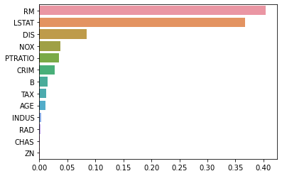

```python
sns.barplot(x=feature_series, y=feature_series.index)
```

- 집값에 미치는 중요도가 가장 큰 변수 6개 선택

본 분석은 직접 주택을 구매하거나, 고객에게 주택을 추천하는 사람의 의사결정을 돕기 위한 목적에서 행하였다. '선택지'의 개수가 많아지면 의사결정에 혼란이 올 수 있으므로, 실용적인 목적에서 중요도 순으로 변수 6개를 선택하였다.

> 참고 : 선택지 개수에 따른 응답의 변화 http://kostat.go.kr/attach/journal/13-2-06.pdf

```python
feature_series.head(6)
```

```
RM         0.404314
LSTAT      0.367514
DIS        0.084744
NOX        0.037223
PTRATIO    0.034440
CRIM       0.027594
dtype: float64
```

### 5. 분석의 결론 : Boston Housing Analysis

- #### Two-Step Regression 방식

#### step 1) 가장 성능 좋은 트리모델 사용, 중요도 순으로 변수 선택

#### Gradient Boost

"집값에 영향을 미치는 요소는 순서대로 **1가구당 방 갯수, 저소득 주민 비율, 5대 고용중심들로부터의 거리, 일산화질소 농도, 학생-선생 비율, 범죄율**입니다."

> 설명변수 채택 : RM, LSTAT, DIS, NOX, PTRATIO, CRIM

참고 :

- Rank Features By Importance https://machinelearningmastery.com/feature-selection-with-the-caret-r-package/
- Variable Importance Through Random Forest https://dataaspirant.com/2018/01/15/feature-selection-techniques-r/
- '선형회귀 분석으로 변수를 선택한다면?' http://ds.sumeun.org/?p=1936

> 최근에 변수를 선택으로 **선형 모형으로 돌려서 유의미한 변수를 추린 후** 다시 인공신경망이나 부스팅 알고리즘과 같은 **비선형 모형으로 분석하겠다**는 얘기를 여러 번 들었다. 하지만 이 방법은 비선형성, 상호작용,그리고 높은 설명변수 상관에 취약하다는 단점이 있다. **대안은** 랜덤포스트와 같은 **비선형 모형에서 변수중요도(variable importance)**를 알아보는 것이다. 특히 **랜덤포레스트는 사전 처리없이 변수를 알아서 선택**해 주는 모형으로 유명하다.

참고 2: 머신러닝 해석 기법을 이용한 전력 수요 예측 모델 해석 http://journal.auric.kr/kiee/XmlViewer/f391863

> 해석가능한 머신러닝을 위해 XGBoost의 입력 특징 중요도와 PDP를 통해 모델을 해석(XGBoost 패키지의 plot_importance 함수와 Skater, SHAP를 사용)

#### step 2) 다중선형회귀 기법 활용, 반응변수의 변화가 목적변수에 미치는 영향 설명

#### Linear Regression

```python
y_target = housing['MEDV']
X_data = housing.drop(['MEDV', 'ZN', 'INDUS', 'CHAS', 'AGE', 'RAD', 'TAX', 'B'], axis=1, inplace=False)

X_train, X_test, y_train, y_test = train_test_split(X_data, y_target, test_size = 0.2, random_state=42)
```

```python
model = LinearRegression()
model.fit(X_train, y_train)

y_train_preds = model.predict(X_train)
y_test_preds = model.predict(X_test)
```

```python
coeff = pd.Series(data=np.round(model.coef_, 3), index=X_data.columns)
coeff.sort_values(ascending=False)
```

```
RM          4.654
CRIM       -0.099
LSTAT      -0.549
PTRATIO    -0.924
DIS        -1.255
NOX       -16.625
dtype: float64
```

```python
coeff * 1000
```

```
CRIM         -99.0
NOX       -16625.0
RM          4654.0
DIS        -1255.0
PTRATIO     -924.0
LSTAT       -549.0
dtype: float64
```

### 6. 모형의 검증

- 본 모델에 사용한 train, test 데이터를 csv로 제작해 R에서 통계적 검증 진행

  > boston_모형검증_R.R 파일

```python
housing_model_train = pd.concat([X_train, y_train], axis=1)
housing_model_test = pd.concat([X_test, y_test], axis=1)
```

```python
housing_model_train.to_csv('housing_model_train.csv', header=True, index=False)
housing_model_test.to_csv('housing_model_test.csv', header=True, index=False)
```

### 참고 : 딥 러닝 모델의 적용 검토

Boston Housing Data는 저차원/소용량 데이터로서 딥러닝을 적용할 필요까지는 없는것으로 판단됨.

> 그러나 '딥러닝'의 장단점/실익을 파악하기 위한 목적으로 본 분석과 별도로 딥 러닝 모델을 적용, 성능 등을 비교해보고자 한다.

```python
# from keras.datasets import boston_housing
# 본 분석과 별로로 진행하므로 과제에 주어진 데이터셋 대신 keras에서 데이터 임포트
# from keras import models, layers
# (X_train, y_train), (X_test, y_test) = boston_housing.load_data()
```

#### 환경 설정 문제로 딥러닝은 다른 머신에서 진행

> boston_참고(딥러닝 비교) 파일